# Power Analysis: Implementing Power Analysis

```r
library(pwr)
```

# 1 t-tests

Example 1: What is the power of a one-tailed t-test, with a significance level of 0.01, 25 people in each group, and an effect size equal to 0.75?

```r
pwr.t.test(n=25,d=0.75,sig.level=.01,alternative="greater")
```

```
##
##      Two-sample t test power calculation
##
##               n = 25
##               d = 0.75
##       sig.level = 0.01
##           power = 0.5988572
##     alternative = greater
##
## NOTE: n is number in *each* group
```

Example 2: Say you’re interested in evaluating the impact of cell phone use on driver reaction time. Let’s assume that you know from past experience that reaction time has a standard deviation of 1.25 seconds. Also suppose that a 1-second difference in reaction time is considered an important difference. Additionally, you want to be 90 percent sure to detect such a difference if it exists, and 95 percent sure that you won’t declare a difference to be significant when it’s actually due to random variability. How many participants will you need in your study?

```r
d.value=1/1.25
pwr.t.test(d = d.value, sig.level = .05, power = .9, type = "two.sample", alternative = "two.sided")
```

```
##
##      Two-sample t test power calculation
##
##               n = 33.82555
##               d = 0.8
##       sig.level = 0.05
##           power = 0.9
##     alternative = two.sided
##
## NOTE: n is number in *each* group
```

The results suggest that you need 34 participants in each group (for a total of 68 participants) in order to detect an effect size of 0.8 with 90 percent certainty and no more than a 5 percent chance of erroneously concluding that a difference exists when, in fact, it doesn’t.

# 2 ANOVA

For a one-way ANOVA comparing 5 groups, calculate the sample size needed in each group to obtain a power of 0.80, when the effect size is moderate (0.25) and a significance level of 0.05 is employed.

```r
pwr.anova.test(k=5,f=.25,sig.level=.05,power=.8)
```

```
##
##      Balanced one-way analysis of variance power calculation
##
##               k = 5
##               n = 39.1534
##               f = 0.25
##       sig.level = 0.05
##           power = 0.8
##
## NOTE: n is number in each group
```

# 3 Correlation

For example, let’s assume that you’re studying the relationship between depression and loneliness. Your null and research hypotheses are $H_{0}:\rho \leq 0.25$ versus $H_{0}:\rho > 0.25$, where $\rho$ is the population correlation between these two psychological variables. You’ve set your significance level to 0.05 and you want to be 90% confident that you’ll reject $H_{0}$ if it’s false. How many observations will you need?

```r
pwr.r.test(r=.25, sig.level=.05, power=.9, alternative="greater")
```

```
##
##      approximate correlation power calculation (arctangh transformation)
##
##               n = 133.2803
##               r = 0.25
##       sig.level = 0.05
##           power = 0.9
##     alternative = greater
```

Thus, you need to assess depression and loneliness in 134 participants in order to be 90% confident that you’ll reject the null hypothesis if it’s false.

# 4 Test of Proportions

Using a two-tailed test proportions, and assuming a significance level of 0.01 and a common sample size of 30 for each proportion, what effect size can be detected with a power of .75?

```r
pwr.2p.test(n=30,sig.level=0.01,power=0.75)
```

```
##
##      Difference of proportion power calculation for binomial distribution (arcsine transformation)
##
##               h = 0.8392269
##               n = 30
##       sig.level = 0.01
##           power = 0.75
##     alternative = two.sided
##
## NOTE: same sample sizes
```

Let’s say that you suspect that a popular medication relieves symptoms in 60% of users. A new (and more expensive) medication will be marketed if it improves symptoms in 65% of users. How many participants will you need to include in a study comparing these two medications if you want to detect a difference this large?

Assume that you want to be 90% confident in a conclusion that the new drug is better and 95% confident that you won’t reach this conclusion erroneously. You’ll use a one-tailed test because you’re only interested in assessing whether the new drug is better than the standard.

```r
pwr.2p.test(h=ES.h(.65,.6), sig.level=.05, power=.9, alternative = "greater")
```

```
##
##      Difference of proportion power calculation for binomial distribution (arcsine transformation)
##
##               h = 0.1033347
##               n = 1604.007
##       sig.level = 0.05
##           power = 0.9
##     alternative = greater
##
## NOTE: same sample sizes
```

Based on these results, you’ll need to conduct a study with 1,605 individuals receiving the new drug and 1,605 receiving the existing drug in order to meet the criteria.

# 5 Creating Power or Sample Size Plots

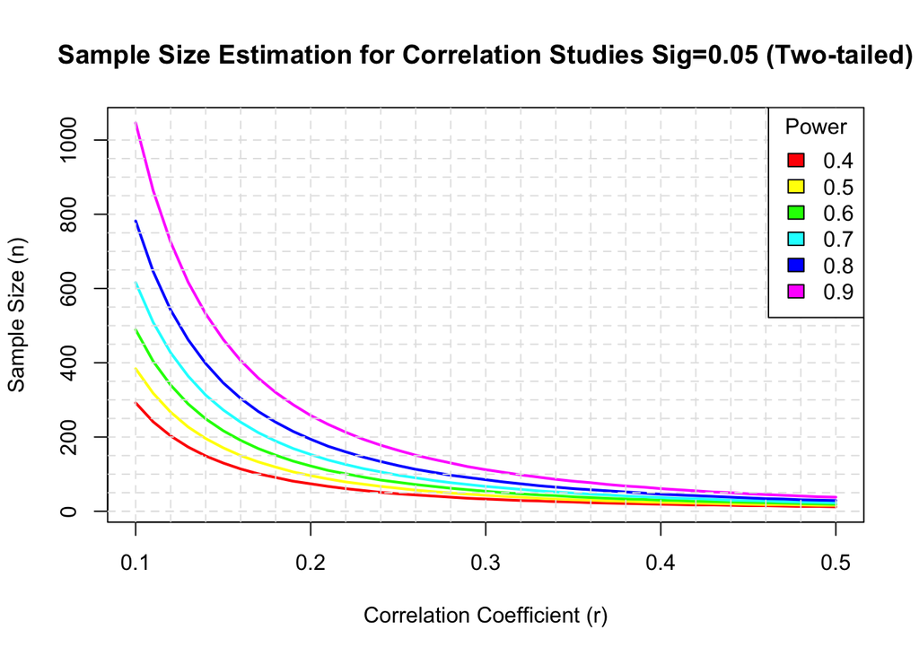

```r
# Plot sample size curves for detecting correlations of
# various sizes.

library(pwr)

# range of correlations
r <- seq(.1,.5,.01)
nr <- length(r)

# power values
p <- seq(.4,.9,.1)
np <- length(p)

# obtain sample sizes
samsize <- array(numeric(nr*np), dim=c(nr,np))
for (i in 1:np){
  for (j in 1:nr){
    result <- pwr.r.test(n = NULL, r = r[j],
    sig.level = .05, power = p[i],
    alternative = "two.sided")
    samsize[j,i] <- ceiling(result$n)
  }
}

# set up graph
xrange <- range(r)
yrange <- round(range(samsize))
colors <- rainbow(length(p))
plot(xrange, yrange, type="n",
  xlab="Correlation Coefficient (r)",
  ylab="Sample Size (n)" )

# add power curves
for (i in 1:np){
  lines(r, samsize[,i], type="l", lwd=2, col=colors[i])
}

# add annotation (grid lines, title, legend)
abline(v=0, h=seq(0,yrange[2],50), lty=2, col="grey89")
abline(h=0, v=seq(xrange[1],xrange[2],.02), lty=2,
   col="grey89")
title("Sample Size Estimation for Correlation Studies Sig=0.05 (Two-tailed)")
legend("topright", title="Power", as.character(p),
   fill=colors)
```